# Least squares fit

To ensure this example is reproducible, we set the seed before beginning.

```r
# Manually set the seed to an arbitrary number for consistency in reports
set.seed(1234)

library(ggplot2)
```

## Creating toy data

We’d like to use the *least squares* fit method to fit a line to some data. Our data will be based on the linear equation

$Y = \beta_0 + \beta_1X + \epsilon ,$

where $Y$ is a response vector, $X$ is an input vector, $\beta_0$ is the y-intercept, $\beta_1$ is the slope of the line and $\epsilon$ is a mean-zero random error term.

For our example data, we choose the model

$Y = 2 + 3X + \epsilon ,$

where $\epsilon$ was generated from a normal distribution with mean zero.

```r
n <- 100
```

We sample **100** points from our model. This will serve as our input data for the least squares fit.

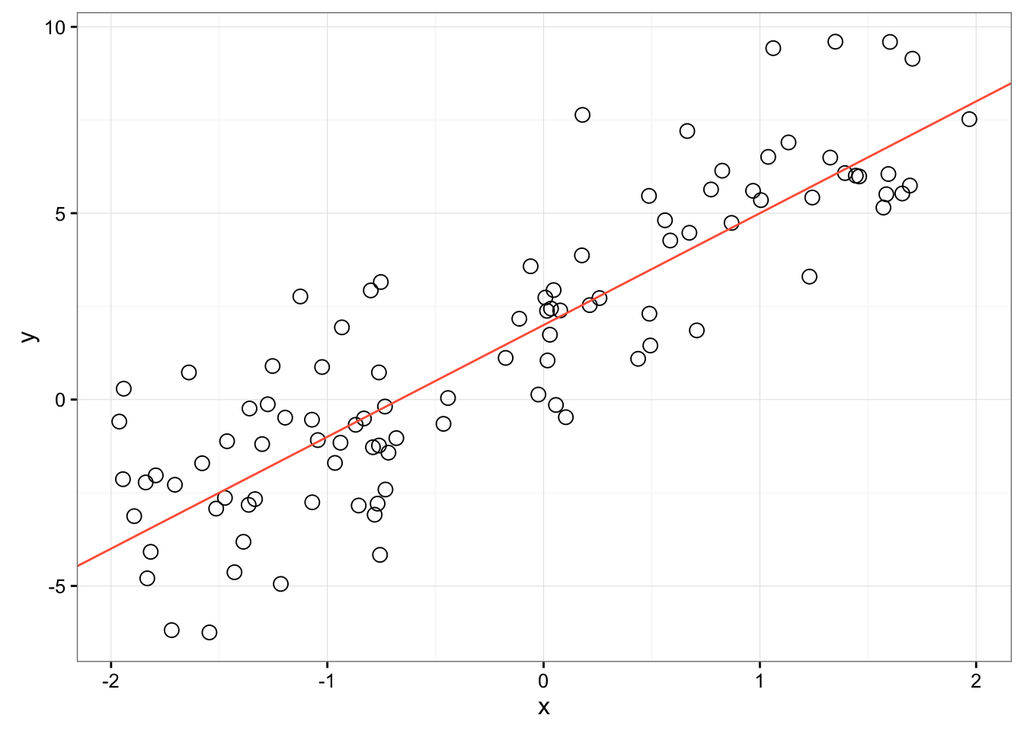

```r
# We use runif to generate random x values from -2 to 2 so that we can compute
# a sampling of y. We use a sd=2 for the error distribution to spread the data
# a bit more.
x <- runif(n, min=-2, max=2)
yIntercept <- 2
slope <- 3
y <- yIntercept + slope * x + rnorm(n, sd=2)

ggplot(NULL, aes(x=x, y=y)) +
  geom_point(pch=1, size=3) +
  geom_abline(intercept=yIntercept, slope=slope, col="tomato") +
  theme_bw()
```

Above, we show our *n = 100* black data points based on the *population regression line* in red. When we fit a linear model to the data, this population regression line is unknown to us.

## Least Squares fit

When computing the least squares fit, our goal is to minimize the *residual sum of squares (RSS)* defined as

$RSS = \displaystyle\sum_{i=1}^{n} (y_i - \hat{y}_i)^2 ,$

where $y_i$ is the $i$-th observed response, $\hat{y}_i$ is the $i$-th predicted response and $(y_i - \hat{y}_i)$ is the $i$-th *residual*.

We now build the model

$\hat{y} = \hat{\beta}_0 + \hat{\beta}_1x ,$

where $\hat{y}$ is a prediction of $Y$ on the basis of $X = x$.

In this attempt, we need to estimate the intercept $\hat{\beta}_0$ and the slope $\hat{\beta}_1$. For each parameter combination, we’ll determine the *RSS* for our *n = 100* points to find the minimum *RSS*.

```r
# precondition: length(yHat) == length(y)
rss <- function(yHat) sum((y - yHat) ^ 2)

leastSquaresFit <- function() {
  minRss <- NULL
  minParams <- NULL

  searchSpace <- seq(-10, 10, length.out=300)
  for (b0 in searchSpace) {
    for(b1 in searchSpace) {
      yHat <- b0 + b1 * x
      if (is.null(minRss) || rss(yHat) < minRss) {
        minRss <- rss(yHat)
        minParams <- list(b0, b1)
      }
    }
  }

  return(minParams)
}

minParams <- leastSquaresFit()
```

Based on our least squares algorithm for the *n = 100* data points, we estimate the model

$\hat{y} = 2.173913 + 2.9765886x$

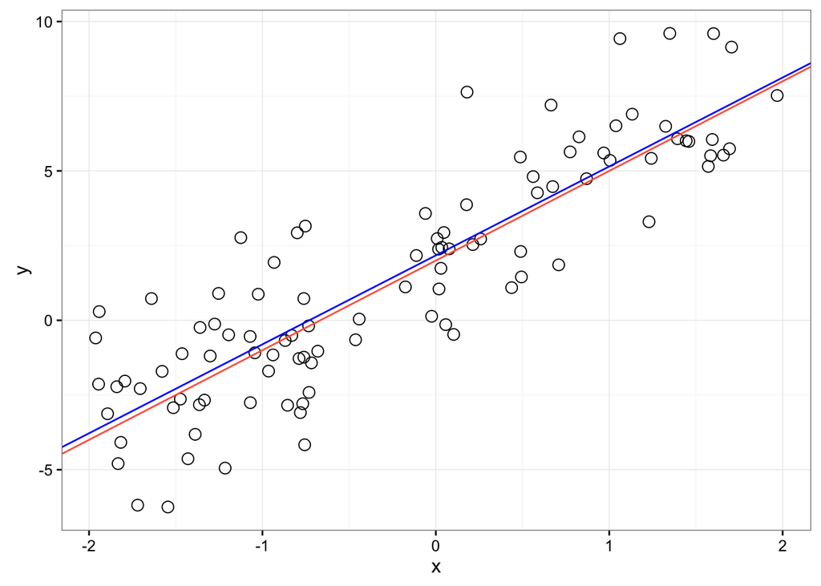

```r
ggplot(NULL, aes(x=x, y=y)) +
  geom_point(pch=1, size=3) +
  geom_abline(intercept=yIntercept, slope=slope, col="tomato") +
  geom_abline(intercept=minParams[[1]], slope=minParams[[2]], col="blue") +
  theme_bw()
```

Plotted alongside the data and the population regression line, we see that our estimate is reasonably accurate.

What happens when we decrease the number of samples points from 100 to 15?

```r
n <- 15

# Using the same population line as before
x <- runif(n, min=-2, max=2)
yIntercept <- 2
slope <- 3
y <- yIntercept + slope * x + rnorm(n, sd=2)

minParams <- leastSquaresFit()
```

Now the model is

$\hat{y} = 2.0401338 + 2.7090301x$

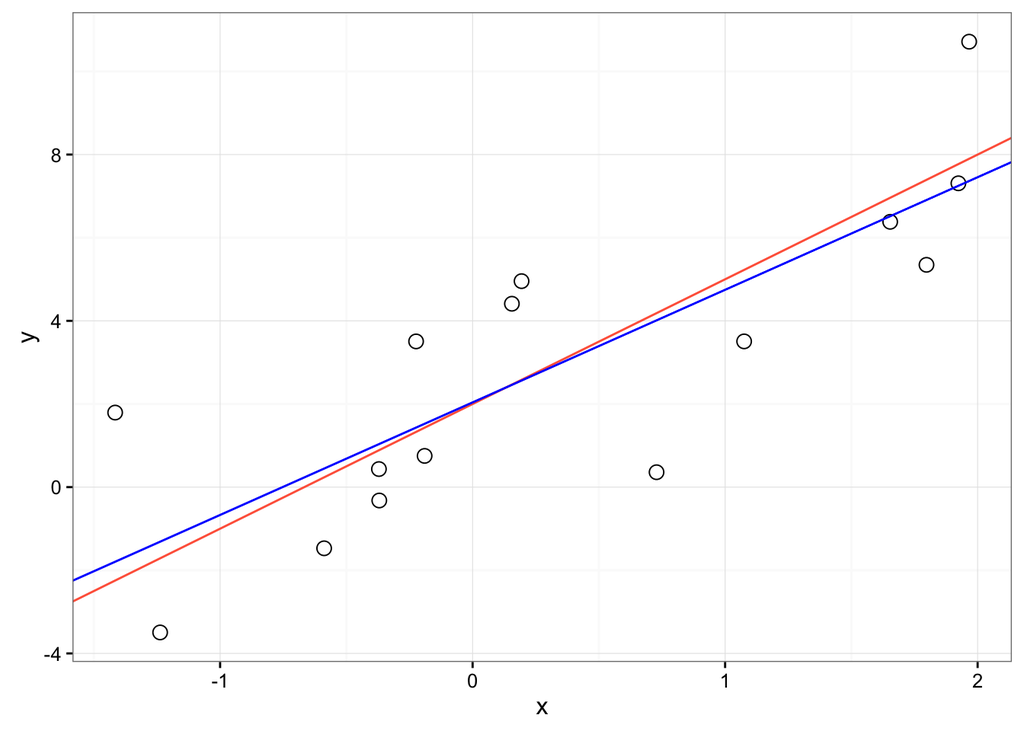

```r
ggplot(NULL, aes(x=x, y=y)) +
  geom_point(pch=1, size=3) +
  geom_abline(intercept=yIntercept, slope=slope, col="tomato") +
  geom_abline(intercept=minParams[[1]], slope=minParams[[2]], col="blue") +
  theme_bw()
```

And the fit is less good.

What if we keep the original sample size, but increase the error?

```r
n <- 100

# Using the same population line as before
x <- runif(n, min=-2, max=2)
yIntercept <- 2
slope <- 3
y <- yIntercept + slope * x + rnorm(n, sd=6)

minParams <- leastSquaresFit()
```

Now the model is

$\hat{y} = 2.7090301 + 3.8461538x$

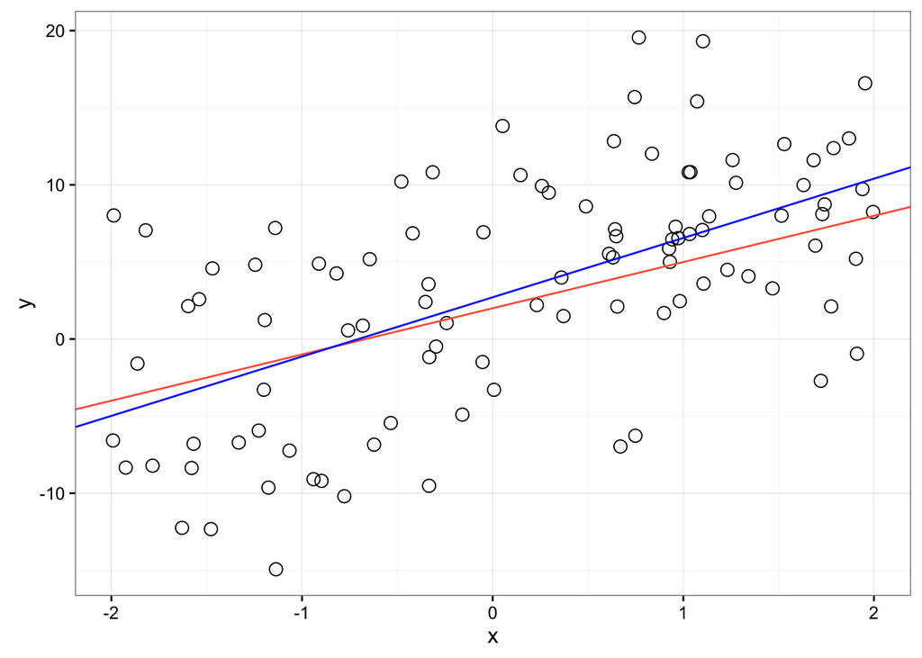

```r
ggplot(NULL, aes(x=x, y=y)) +
  geom_point(pch=1, size=3) +
  geom_abline(intercept=yIntercept, slope=slope, col="tomato") +
  geom_abline(intercept=minParams[[1]], slope=minParams[[2]], col="blue") +
  theme_bw()
```

And, finally, with many sampled data points and a decreased error

```r
n <- 100

# Using the same population line as before
x <- runif(n, min=-2, max=2)
yIntercept <- 2
slope <- 3
y <- yIntercept + slope * x + rnorm(n, sd=1)

minParams <- leastSquaresFit()
```

Now the model is

$\hat{y} = 2.0401338 + 2.909699x$

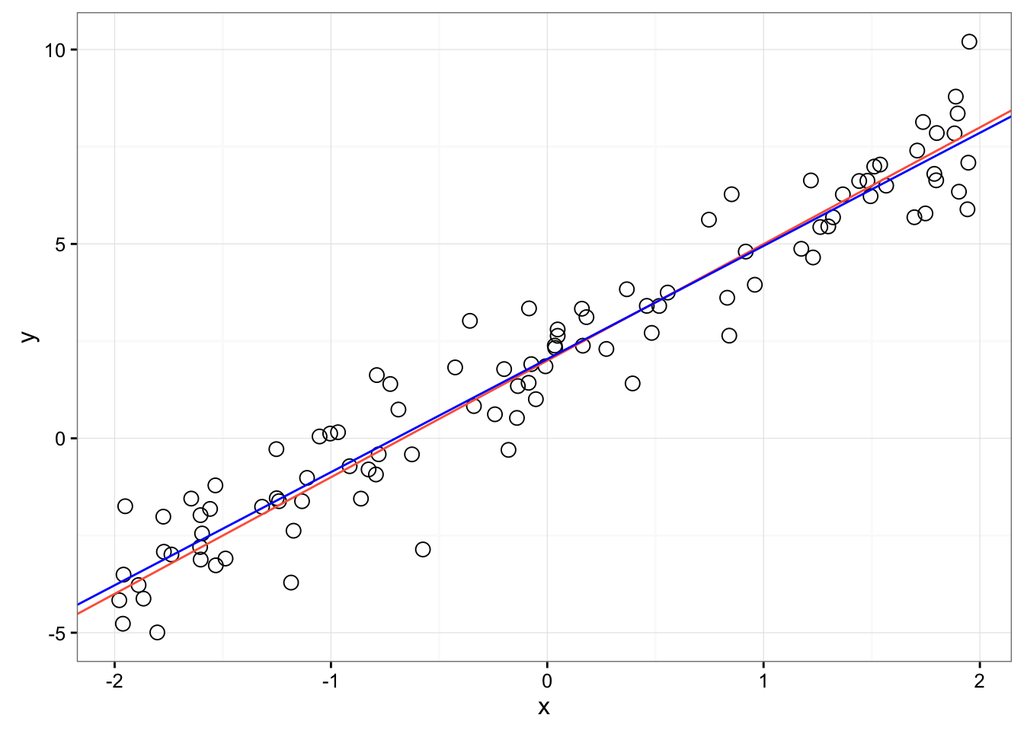

```r
ggplot(NULL, aes(x=x, y=y)) +
  geom_point(pch=1, size=3) +
  geom_abline(intercept=yIntercept, slope=slope, col="tomato") +
  geom_abline(intercept=minParams[[1]], slope=minParams[[2]], col="blue") +
  theme_bw()
```

As expected, increasing the number of points, or decreasing the error (or both) results in an improved model estimate.

**NOTE:* Here, I attempted to write a naive method to build linear models. Using `R`’s built-in `lm()` function, we get the following

```r
# Create the original sample data:
x <- runif(n, min=-2, max=2)
yIntercept <- 2
slope <- 3
y <- yIntercept + slope * x + rnorm(n, sd=2)

rModel <- lm(y ~ x)
```

The model output by base `R`’s function is

$\hat{y} = 1.6999119 + 3.109847x$

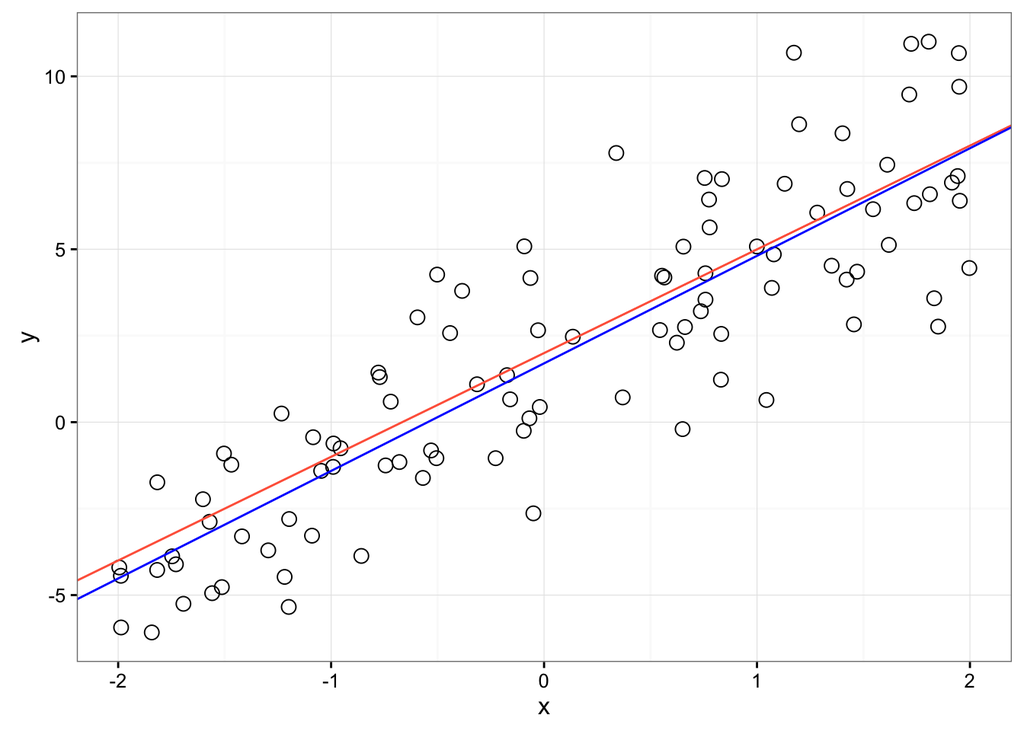

```r
ggplot(NULL, aes(x=x, y=y)) +
  geom_point(pch=1, size=3) +
  geom_abline(intercept=yIntercept, slope=slope, col="tomato") +
  geom_abline(intercept=rModel$coefficients[[1]], slope=rModel$coefficients[[2]], col="blue") +
  theme_bw()
```

We’ve done a reasonable job approximating the output from `lm()`.

If we want to use the least squares minimizers (see [James *et al* (2013)](http://www-bcf.usc.edu/~gareth/ISL/), pg. 62), these are defined as

$\hat{\beta}_1 = \frac{\sum_{i=1}^{n} (x_i - \bar{x}) (y_i - \bar{y}) }{\sum_{i=1}^{n} (x_i - \bar{x})^2}$ ,

$\hat{\beta}_0 = \bar{y} - \hat{\beta}_1 \bar{x}$

```r
# Continuing with the x and y from the previous example where lm() was applied
numerator <- 0
denominator <- 0
for (i in 1:n) {
  numerator <- numerator + (x[i] - mean(x)) * (y[i] - mean(y))
  denominator <- denominator + (x[i] - mean(x)) ^ 2
}

lsMinSlope <- numerator / denominator
lsMinIntercept <- mean(y) - lsMinSlope * mean(x)
```

Our minimizer-based model is

$\hat{y} = 1.6999119 + 3.109847x$

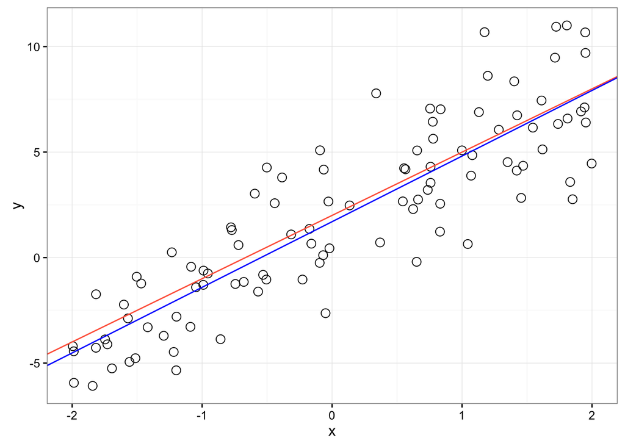

```r
ggplot(NULL, aes(x=x, y=y)) +
  geom_point(pch=1, size=3) +
  geom_abline(intercept=yIntercept, slope=slope, col="tomato") +
  geom_abline(intercept=lsMinIntercept, slope=lsMinSlope, col="blue") +
  theme_bw()
```

This matches with the output from `R`’s `lm()` function, and, unlike our naive method, doesn’t require a grid-search-like algorithm.

## Future directions

Later, we can assess the goodness-of-fit using $R^2$

## System Information

*Time required to process this report:* *4.442355 secs*